# Cohort_Analysis slides

### Dataset: Members of US Congress (Past & Present)

### Framework: Cohort Analysis

### Analyses:

```
   1- Retention
   2- Survivorship
```

#### Importing Modules and Libraries needed.

```python
import math
import numpy as np
import pandas as pd
import matplotlib.pyplot as pp
import psycopg2
```

#### Connecting to the DB.

```python
dbconn = psycopg2.connect("dbname=Retail user=doctaa password=pass!")
cur = dbconn.cursor()
```

### 1 - Rention Analysis

#### Q1: How long do representatives keep their jobs after taking office ?

```python
#This is the query for retrieving the data

sql1 = 'SELECT date_part(\'year\', age(b.term_start, a.first_term)) as period, count (distinct a.id_bioguide) \
FROM \
(\
    SELECT id_bioguide, min(term_start) as first_term \
    FROM \"congress\".legislators_terms \
    GROUP BY 1 \
    ) a \
JOIN \"congress\".legislators_terms b on a.id_bioguide = b.id_bioguide \
GROUP BY 1 order by 1 \
;'
```

```python
cur.execute("ROLLBACK")     # Reset the connection just in case there were previous connection errors
dbconn.commit()             # Save the changes
cur.execute(sql1)           # Execute the new query
result1 = cur.fetchall()    # Retrieve the data from the query and save it in a variable
legisdf = pd.DataFrame(result1) #Convert the fetched Data in a DataFrame
```

```python
legisdf.columns=['Period','ReCoSize'] #Nameing the columns in the data frame
```

```python
#using lambda to add a column containing the cohort size to our df
legisdf = legisdf.assign(CoSize= lambda x: x['ReCoSize'].iloc[0])
```

```python
legisdf['RetRate'] = round((legisdf['ReCoSize']/legisdf['CoSize']), 4)*100
```

```python
legisdf.head() # Sample of data in our df. Showing the first 5 items.
```

|  | Period | ReCoSize | CoSize | RetRate |
| --- | --- | --- | --- | --- |
| 0 | 0.0 | 12518 | 12518 | 100.00 |
| 1 | 1.0 | 3600 | 12518 | 28.76 |
| 2 | 2.0 | 3619 | 12518 | 28.91 |
| 3 | 3.0 | 1831 | 12518 | 14.63 |
| 4 | 4.0 | 3210 | 12518 | 25.64 |

##### Obesrvation 1:

The graph bellow show a big drop in the retention rate and then a few years of jagged rate before flattening out. This is because in our data, we only have the start date for every term. The end date is missing, so calculating the retention rate in this format is presenting a false positive.

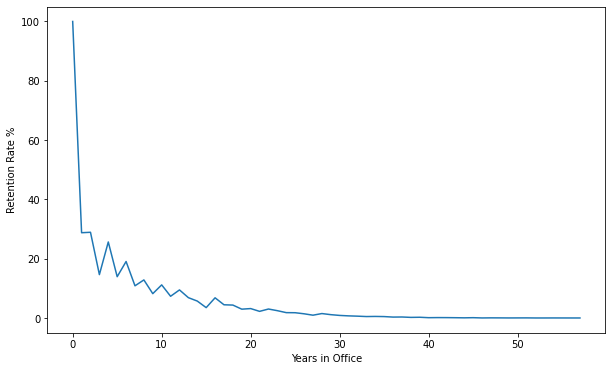

```python
x = legisdf['Period']
y = legisdf['RetRate']

pp.figure(figsize = (10,6))
pp.plot(x,y)
pp.xlabel('Years in Office')
pp.ylabel('Retention Rate %')
```

#### Normalizing the Analysis

```python
sql1_1 = 'select * from \"congress\".norm_cohort_count'
cur.execute("ROLLBACK")
dbconn.commit()
cur.execute(sql1_1)
result1_1 = cur.fetchall()
legisdf2 = pd.DataFrame(result1_1)
```

```python
legisdf2.columns=['Period','RetCo']
```

```python
legisdf2 = legisdf2.assign(CoSize= lambda x: x['RetCo'].iloc[0])
```

```python
legisdf2['Rate'] = round(legisdf2['RetCo']/legisdf2['CoSize'], 4)*100
```

```python
legisdf2.head()
```

|  | Period | RetCo | CoSize | Rate |
| --- | --- | --- | --- | --- |
| 0 | 0.0 | 12518 | 12518 | 100.00 |
| 1 | 1.0 | 12328 | 12518 | 98.48 |
| 2 | 2.0 | 8162 | 12518 | 65.20 |
| 3 | 3.0 | 8065 | 12518 | 64.43 |
| 4 | 4.0 | 5853 | 12518 | 46.76 |

##### Obersavtion 2:

In the graph bellow, a date table was generated and joined to the existing table. By doing this, every year now has an end date, rentention can be better tracked. This allows the us to normalize the data and increase the accuracy of our graph. We notice the drop in retention is not a drastic anymore.

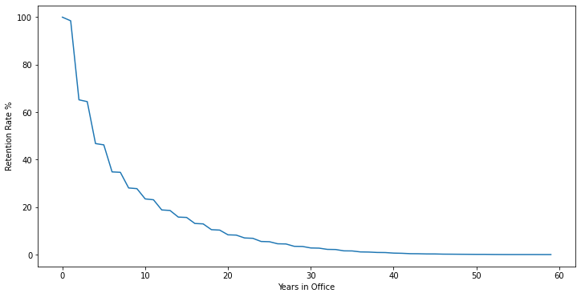

```python
x1 = legisdf2['Period']
y1 = legisdf2['Rate']

pp.figure(figsize=(12,6))
pp.plot(x1,y1)
pp.xlabel('Years in Office')
pp.ylabel('Retention Rate %')
```

#### Q2: Does the era in which a legislator first take office has any correlation with their retention ?

##### Query for checking the correlation:

# CREATE VIEW congress.century_cohort AS SELECT century, period ,first_value(cohort_retained) over (partition by century order by period) as cohort_size ,cohort_retained FROM ( SELECT date_part('century', first_term) as century, coalesce(date_part('year',age(c.date,a.first_term)),0) as Period, count(distinct a.id_bioguide) as cohort_retained FROM( SELECT id_bioguide, min(term_start) as first_term FROM "congress".legislators_terms GROUP BY 1) a JOIN congress.legislators_terms b on a.id_bioguide = b.id_bioguide LEFT JOIN congress.datetable c on c.date between b.term_start and b.term_end GROUP BY 1,2 ) aa WHERE century < 21 ;

```python
sql1_2 = 'select * from \"congress\".century_cohort' #The results of the query are saved in a view and read into a df for visualization
cur.execute("ROLLBACK")
dbconn.commit()
cur.execute(sql1_2)
result1_1 = cur.fetchall()
legisdf3 = pd.DataFrame(result1_1)
```

```python
legisdf3.columns = ['Century','Period','CoSize','CoRetained']
```

```python
legisdf3['Rate']=round(legisdf3['CoRetained']/legisdf3['CoSize'], 4)
```

```python
legisdf3.head() #sample from dataframe
```

|  | Century | Period | CoSize | CoRetained | Rate |
| --- | --- | --- | --- | --- | --- |
| 0 | 18.0 | 0.0 | 368 | 368 | 1.0000 |
| 1 | 18.0 | 1.0 | 368 | 360 | 0.9783 |
| 2 | 18.0 | 2.0 | 368 | 242 | 0.6576 |
| 3 | 18.0 | 3.0 | 368 | 233 | 0.6332 |
| 4 | 18.0 | 4.0 | 368 | 149 | 0.4049 |

##### Obersvation 3:

Given our Graph below, we can answer that there is a correlation between the retentation rate and the term the legislators started. the legislators are put in cohort of centuries and the main difference noticed is that retention rate in both the 18th and 19th century dropped faster that that of the 201th century.

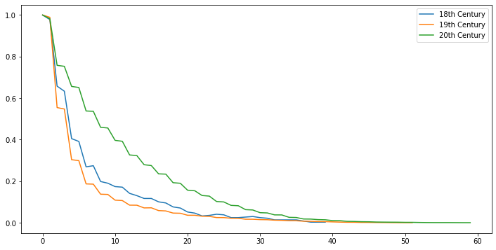

```python
x3_1 = legisdf3[legisdf3['Century']==18.0]['Period']
x3_2 = legisdf3[legisdf3['Century']==19.0]['Period']
x3_3 = legisdf3[legisdf3['Century']==20.0]['Period']

y3_1 = legisdf3[legisdf3['Century']==18.0]['Rate']
y3_2 = legisdf3[legisdf3['Century']==19.0]['Rate']
y3_3 = legisdf3[legisdf3['Century']==20.0]['Rate']


pp.figure(figsize=(12,6))
pp.plot(x3_1,y3_1, label = '18th Century')
pp.plot(x3_2,y3_2, label = '19th Century')
pp.plot(x3_3,y3_3, label = '20th Century')

pp.legend()
```

### 2 - Survivorship

#### Q3: What percentage of legislators survived in office for two decades or more after their first term started?

##### Query for answer the question:

```python
sql2 = 'select * from \"congress\".survivor' #Read the view into a df from postgres
cur.execute("ROLLBACK")
dbconn.commit()
cur.execute(sql2)
survivordf = pd.DataFrame(cur.fetchall())
```

```python
survivordf.columns = ['Century', 'CoSize', 'Survivors']
```

```python
survivordf['SurRate']=round(survivordf['Survivors']/survivordf['CoSize'], 4)
```

##### Obersavtion 4

The df result diplayed below shows the survival percentage of each cohort. The legislators are arranged in cohorts of centuries. To add more granularity to the result, we can modify query to reflect the approriate level of granularty we're seeking. There's no answer for the 21st century as we're still in the second decade of the second century

```python
survivordf #DataFrame showing the survival rate.
```

|  | Century | CoSize | Survivors | SurRate |
| --- | --- | --- | --- | --- |
| 0 | 18.0 | 368 | 25 | 0.0679 |
| 1 | 19.0 | 6299 | 278 | 0.0441 |
| 2 | 20.0 | 5091 | 705 | 0.1385 |
| 3 | 21.0 | 760 | 0 | 0.0000 |